# EDA SIP

## O que são os dados

```
## Observations: 12,299
## Variables: 17
## $ TaskNumber           <chr> "1735", "1742", "1971", "2134", "2251", "...
## $ Summary              <chr> "Flag RI on SCM Message Summary screen us...
## $ Priority             <dbl> 1, 1, 2, 5, 10, 1, 5, 5, 6, 5, 2, 1, 3, 1...
## $ RaisedByID           <chr> "58", "58", "7", "50", "46", "13", "13", ...
## $ AssignedToID         <chr> "58", "42", "58", "42", "13", "13", "13",...
## $ AuthorisedByID       <chr> "6", "6", "6", "6", "6", "58", "6", "6", ...
## $ StatusCode           <chr> "FINISHED", "FINISHED", "FINISHED", "FINI...
## $ ProjectCode          <chr> "PC2", "PC2", "PC2", "PC2", "PC2", "PC9",...
## $ ProjectBreakdownCode <chr> "PBC42", "PBC21", "PBC75", "PBC42", "PBC2...
## $ Category             <chr> "Development", "Development", "Operationa...
## $ SubCategory          <chr> "Enhancement", "Enhancement", "In House S...
## $ HoursEstimate        <dbl> 14.00, 7.00, 0.70, 0.70, 3.50, 7.00, 7.00...
## $ HoursActual          <dbl> 1.75, 7.00, 0.70, 0.70, 3.50, 7.00, 7.00,...
## $ DeveloperID          <chr> "58", "42", "58", "42", "13", "13", "43",...
## $ DeveloperHoursActual <dbl> 1.75, 7.00, 0.70, 0.70, 3.50, 7.00, 7.00,...
## $ TaskPerformance      <dbl> 12.25, 0.00, 0.00, 0.00, 0.00, 0.00, 0.00...
## $ DeveloperPerformance <dbl> 12.25, 0.00, 0.00, 0.00, 0.00, 0.00, NA, ...
```

## Entendendo os dados

```
## Skim summary statistics
##  n obs: 12299
##  n variables: 4
##
## ── Variable type:character ───────────────────────────────────────────────────────────────────────────────
##     variable missing complete     n min max empty n_unique
##  ProjectCode       0    12299 12299   3   4     0       20
##   TaskNumber       0    12299 12299   4   5     0    10266
##
## ── Variable type:numeric ─────────────────────────────────────────────────────────────────────────────────
##       variable missing complete     n  mean    sd   p0 p25 p50 p75    p100
##    HoursActual       0    12299 12299 13.18 68.72 0.01   1   3 8.5 2490.16
##  HoursEstimate       0    12299 12299 10.15 28.84 0.01   1   3 7    910
##      hist
##  ▇▁▁▁▁▁▁▁
##  ▇▁▁▁▁▁▁▁
```

Temos 20 projetos, com 12299 estimativas_raw. Não há apenas uma estimativa por tarefa, já que há apenas 10266 valores distintos de `TaskNumber`.

```
## # A tibble: 1,384 x 2
## # Groups:   TaskNumber [1,384]
##    TaskNumber     n
##    <chr>      <int>
##  1 10605          8
##  2 6889           8
##  3 10089          7
##  4 10974          7
##  5 11056          7
##  6 11270          7
##  7 13124          7
##  8 13190          7
##  9 13253          7
## 10 3812           7
## # ... with 1,374 more rows
```

## Qual a relação entre as estimativas e horas reais tomadas na empresa como um todo e em diferentes categorias de tarefa?

### Em toda empresa

Para avaliar a relação entre as horas estimadas e reais utilizaremos o gráfico abaixo, vale lembrar que a escola usada nos dois eixos é **log10**. A linha pontinhada indica os casos em que a estimativa acertou exatamente as horas gastas na task.

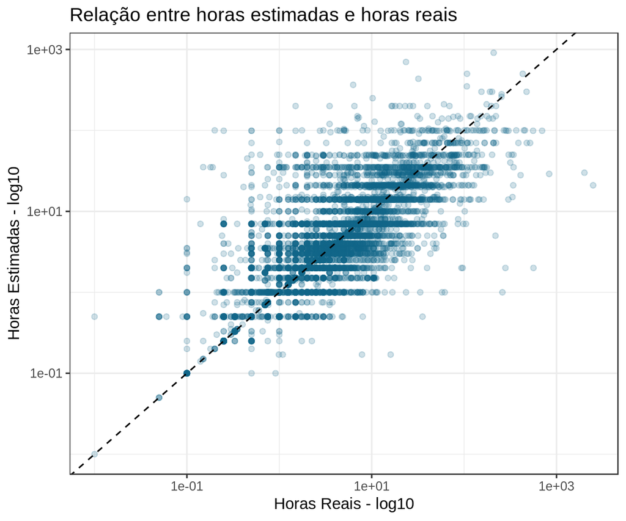

Observamos que os pontos estão distribuídos mais ou menos ao redor da linha tracejada, o que é um indício de uma correlação linear forte entre o logaritmo na base 10 das Horas estimadas e o logarimo na base 10 das Horas exatas.

Podemos calcular a correlação entre as duas variáveis, para tal utilizaremos os três métodos mais conhecidos:

- Pearson
- Spearman
- Kendal

| **Pearson** | **Spearman** | **Kendall** |
| --- | --- | --- |
| 0.8157413 | 0.8260454 | 0.6958933 |

Os valores de correlação confirmam as suspeitas da existência de uma **correlação positiva forte** entre o log10 das variáveis.

*Lembrando que a correlação observada é entre o log10 das duas variáveis, não podemos dizer que há uma correlação linear forte entre Horas estimadas e Horas exatas, mas podemos dizer isso do log10 das mesmas*

### Por categoria

A visualização usada aqui é bem similiar a anterior, mas neste caso, estamos separando por categoria.

Mais uma vez **as variáveis estão em log10**.

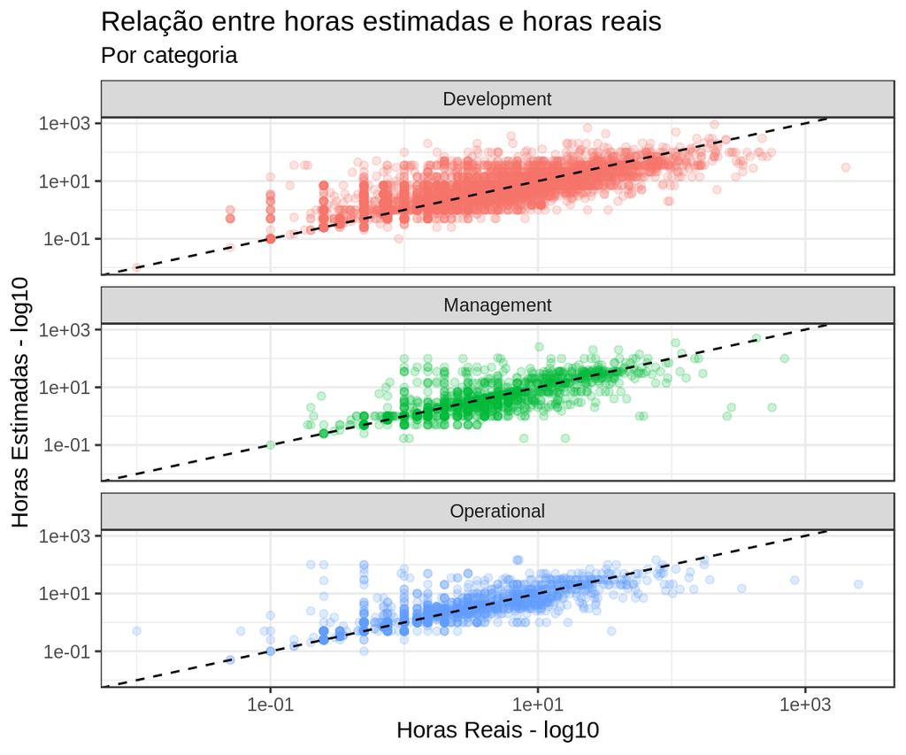

Similarmente à visão geral temos indícios de correlação positiva forte entre as Horas estimadas e as Horas reais para todas as categorias. Vamos tentar mensurar essa relação, mais uma vez, através das medidas de correlação.

| Category | pearson | spearman | kendall |
| --- | --- | --- | --- |
| Development | 0.8269926 | 0.8345521 | 0.7002424 |
| Management | 0.7486415 | 0.7528142 | 0.6348328 |
| Operational | 0.8116314 | 0.8416869 | 0.7292038 |

Vemos que os valores indicam a **existência de correlação linear forte entre o log10 das variáveis**.

Os valores da correlação Kendal são menores que os demais, mas esse comportamento já é esperado pois esse método apresenta, em geral, valores menores que os outros dois métodos.

## Equipes com mais desenvolvedores produzem estimativas com mais ou menos erro que equipes menores?

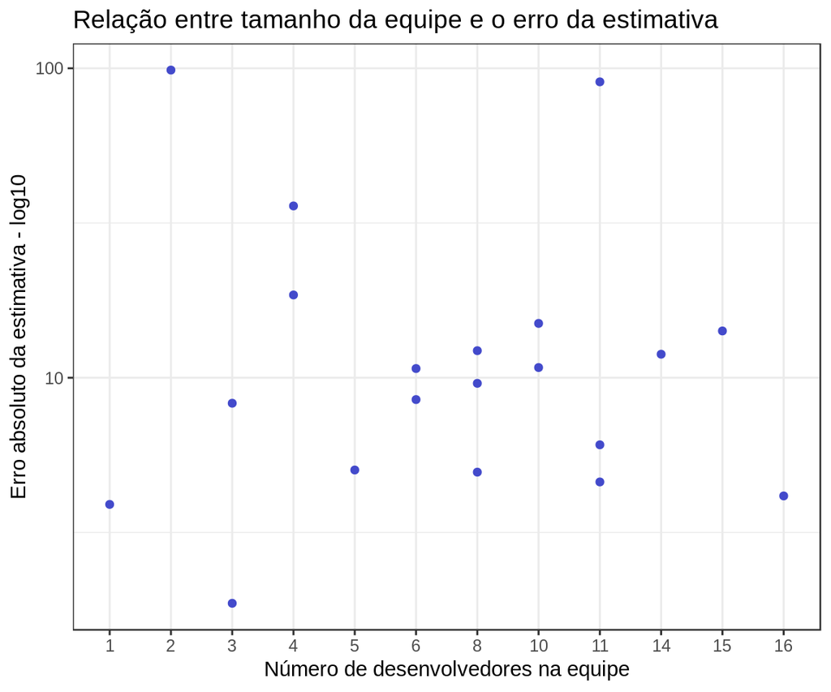

Pela visualização não é possível observar nenhuma tendência no valor do erro quando variado o tamanho da equipe, o que é um indicativo de que não existe relação entre esses dois fatores, observando o valor da correlação:

| **Pearson** | **Spearman** | **Kendall** |
| --- | --- | --- |
| -0.0327 | 0.0438071 | 0.0324443 |

Observamos que os valores são bem próximos a zero o que indica que **não há correlação linear** entre e logaritmo na base 10 do erro absoluto da estimativa e o número de desenvolvedores da equipe.